# Data mining, concepts and techniques

# ANOVA method

1. Create groups for the variable “year” G1: year < 73 G2: 73 <= year < 76 G3: 76 <= year < 79 G4: year >= 79
2. Apply ANOVA to identify if there are differences in MPG for the created groups. Interpretation of results.
3. Explain the meaning of SSW, SSB and SST in a variance analysis. How are these calculations used to check if there are differences between groups?
4. In case of significative difference between groups, calculate a posteriori test (post-hoc test) like Tukey test. Interpretation of results.

A)Create groups for the variable “year”

```r
#I use the package "dplyr" for data manipulation. I create 4 dataframes, where I will filter with every group condition.
#Afterwards, in a new dataframe, I join the 4 groups with the column name Group
#In this dataframe (df3) ANOVA can be applied directly.

library(dplyr)

G1<-coches %>%
  filter (año<73)
head(G1)
```

```
##   mpg cilindros cilindrada  CV peso aceleración año origen
## 1  18         8        307 130 3504        12.0  70      1
## 2  15         8        350 165 3693        11.5  70      1
## 3  18         8        318 150 3436        11.0  70      1
## 4  16         8        304 150 3433        12.0  70      1
## 5  17         8        302 140 3449        10.5  70      1
## 6  15         8        429 198 4341        10.0  70      1
##                          ID
## 1 chevrolet chevelle malibu
## 2         buick skylark 320
## 3        plymouth satellite
## 4             amc rebel sst
## 5               ford torino
## 6          ford galaxie 500
```

```r
tail(G1)
```

```
##    mpg cilindros cilindrada CV peso aceleración año origen
## 80  26         4         96 69 2189        18.0  72      2
## 81  22         4        122 86 2395        16.0  72      1
## 82  28         4         97 92 2288        17.0  72      3
## 83  23         4        120 97 2506        14.5  72      3
## 84  28         4         98 80 2164        15.0  72      1
## 85  27         4         97 88 2100        16.5  72      3
##                             ID
## 80             renault 12 (sw)
## 81             ford pinto (sw)
## 82             datsun 510 (sw)
## 83 toyouta corona mark ii (sw)
## 84             dodge colt (sw)
## 85    toyota corolla 1600 (sw)
```

```r
G2<-coches %>%
  filter (72<año & año<76)

G3<-coches %>%
  filter (75<año & año<79)


G4<-coches %>%
  filter (78<año)
head(G4)
```

```
##    mpg cilindros cilindrada  CV peso aceleración año origen
## 1 21.5         6        231 115 3245        15.4  79      1
## 2 19.8         6        200  85 2990        18.2  79      1
## 3 22.3         4        140  88 2890        17.3  79      1
## 4 20.2         6        232  90 3265        18.2  79      1
## 5 20.6         6        225 110 3360        16.6  79      1
## 6 17.0         8        305 130 3840        15.4  79      1
##                          ID
## 1         pontiac lemans v6
## 2          mercury zephyr 6
## 3           ford fairmont 4
## 4          amc concord dl 6
## 5             dodge aspen 6
## 6 chevrolet caprice classic
```

```r
tail(G4)
```

```
##     mpg cilindros cilindrada CV peso aceleración año origen
## 113  27         4        151 90 2950        17.3  82      1
## 114  27         4        140 86 2790        15.6  82      1
## 115  44         4         97 52 2130        24.6  82      2
## 116  32         4        135 84 2295        11.6  82      1
## 117  28         4        120 79 2625        18.6  82      1
## 118  31         4        119 82 2720        19.4  82      1
##                   ID
## 113 chevrolet camaro
## 114  ford mustang gl
## 115        vw pickup
## 116    dodge rampage
## 117      ford ranger
## 118       chevy s-10
```

```r
df3 <- dplyr::bind_rows(list(G1, G2, G3, G4), .id = 'Grupo')
head(df3)
```

```
##   Grupo mpg cilindros cilindrada  CV peso aceleración año origen
## 1     1  18         8        307 130 3504        12.0  70      1
## 2     1  15         8        350 165 3693        11.5  70      1
## 3     1  18         8        318 150 3436        11.0  70      1
## 4     1  16         8        304 150 3433        12.0  70      1
## 5     1  17         8        302 140 3449        10.5  70      1
## 6     1  15         8        429 198 4341        10.0  70      1
##                          ID
## 1 chevrolet chevelle malibu
## 2         buick skylark 320
## 3        plymouth satellite
## 4             amc rebel sst
## 5               ford torino
## 6          ford galaxie 500
```

```r
tail(df3)
```

```
##     Grupo mpg cilindros cilindrada CV peso aceleración año origen
## 393     4  27         4        151 90 2950        17.3  82      1
## 394     4  27         4        140 86 2790        15.6  82      1
## 395     4  44         4         97 52 2130        24.6  82      2
## 396     4  32         4        135 84 2295        11.6  82      1
## 397     4  28         4        120 79 2625        18.6  82      1
## 398     4  31         4        119 82 2720        19.4  82      1
##                   ID
## 393 chevrolet camaro
## 394  ford mustang gl
## 395        vw pickup
## 396    dodge rampage
## 397      ford ranger
## 398       chevy s-10
```

2. Apply ANOVA to identify if there are differences in MPG for the created groups. Interpretation of results.

As we see in the summary here shown, Pr(>F) has *** in significance level, this means that we can assure with accuracy that MPG means for every group are differents. Pr(>F) gives the accuracy that we have on the affirmation of “our calculated F (69.5) is higher than critical F”. (In that case, H_o from test must be discarded, this H_o is “means are similar between groups”)

```r
set.seed(1)
ANOVAmpg <- aov(df3$mpg~df3$Grupo, data=df3)

ANOVAmpg
```

```
## Call:
##    aov(formula = df3$mpg ~ df3$Grupo, data = df3)
##
## Terms:
##                 df3$Grupo Residuals
## Sum of Squares    8392.50  15860.08
## Deg. of Freedom         3       394
##
## Residual standard error: 6.344604
## Estimated effects may be unbalanced
```

```r
summary(ANOVAmpg)
```

```
##              Df Sum Sq Mean Sq F value Pr(>F)
## df3$Grupo     3   8393  2797.5    69.5 <2e-16 ***
## Residuals   394  15860    40.3
## ---
## Signif. codes:  0 '***' 0.001 '**' 0.01 '*' 0.05 '.' 0.1 ' ' 1
```

3. Explain the meaning of SSW, SSB and SST in a variance analysis. How are these calculations used to check if there are differences between groups?

*SSB (sum of squares between) is the sum of variances between groups (sum Sq) for groups = 8393*

*SSW (sum of squares within) is the sum of variances intragroup (sum Sq) for Residuals = 15860*

*SST (sum of squares total) is the sum of variances between groups and intragroups. SST = SSB+ SSW*

*ANOVA checks the null hypothesis of “every group mean, is the same”*.

Differently from test t, ANOVA can be used to check differences between more than 2 groups. If the null hypothesis is rejected, it means that at least one of the groups, has a mean significantly different from the rest (although we still don’t know which group)

If we want to know which groups create the difference, we use the Tukey test [Tukey’s Honestly Significantly Different(HSD)].

ANOVA is based in two population variance(σ2) estimators, the mean squared error (MSE) and the squared mean between groups (MSB).

MSE is based in the differences between groups, and MSB is based in the differences between sample means

MSE estimates σ2 without checking if the null hypothesis is true (same sample means).

MSB estimates σ2 only if the sample means are equal. If they are different, then MSB estimates a higher amount than σ2.

Therefore, if MSB is much greater than MSE, the sample means can not be equal. In the opposite case, if MSB is near to MSE, then the data confirm the null hypothesis “sample means are equal”

In practice, knowing SSW and SSB, and the freedom degrees for every group (determined by the number of groups and number of observations), we can calculate the F value (69.5 in this case). If this value is out of the critical F for a Fisher distribution and a given alpha and our freedom degrees (3.394), then we reject the H_o (and we know it is outside limits, checking Pr(>F) in the aov summary)

```r
#F critical value:
qf(0.05, 3, 394, lower.tail=F)
```

```
## [1] 2.627556
```

4. In case of significative difference between groups, calculate a posteriori test (post-hoc test) like Tukey test. Interpretation of results.

*Conclussions:*

“P adj” for groups 1-2 is 0.96, which shows a high probability of having a small means difference between these 2 groups. In the rest of groups we find a very low “p adj”. This indicates that the means difference between these groups, is very high.

Groups 1 and 2 correspond to cars manufactured before 1973, and from 73 to 76 respectively. We can conclude that during these two periods, there were any significative improvement in the fuel consumption level of vehicles. However, if we compare the next groups (2-3), we see that the means difference is significative, and positive, so for this period (76-79), there was an improvement in vehicles mean MPG.

The other groups have an even bigger difference level, being the greatest difference between groups 1 and 4, as we could expect.

We can conclude that from year 76 to past year 79, the cars increased their mean MPG, and from 73 to 76, the mean MPG was constant.

```r
#Tukey HSD test
library(ggplot2)

Tuk<-TukeyHSD(ANOVAmpg, conf.level = 0.99)
Tuk
```

```
##   Tukey multiple comparisons of means
##     99% family-wise confidence level
##
## Fit: aov(formula = df3$mpg ~ df3$Grupo, data = df3)
##
## $`df3$Grupo`
##           diff        lwr       upr     p adj
## 2-1  0.4391753 -2.5144025  3.392753 0.9664485
## 3-1  3.8020408  0.8555093  6.748572 0.0003685
## 4-1 11.0338983  8.2057277 13.862069 0.0000000
## 3-2  3.3628656  0.5156100  6.210121 0.0013977
## 4-2 10.5947230  7.8701378 13.319308 0.0000000
## 4-3  7.2318575  4.5149123  9.948803 0.0000000
```

```r
#converting to dataframe to be able to use it:
DF_tuk <- as.data.frame.matrix(Tuk$`df3$Grupo`)
DF_tuk
```

```
##           diff        lwr       upr        p adj
## 2-1  0.4391753 -2.5144025  3.392753 0.9664485083
## 3-1  3.8020408  0.8555093  6.748572 0.0003684581
## 4-1 11.0338983  8.2057277 13.862069 0.0000000000
## 3-2  3.3628656  0.5156100  6.210121 0.0013976923
## 4-2 10.5947230  7.8701378 13.319308 0.0000000000
## 4-3  7.2318575  4.5149123  9.948803 0.0000000000
```

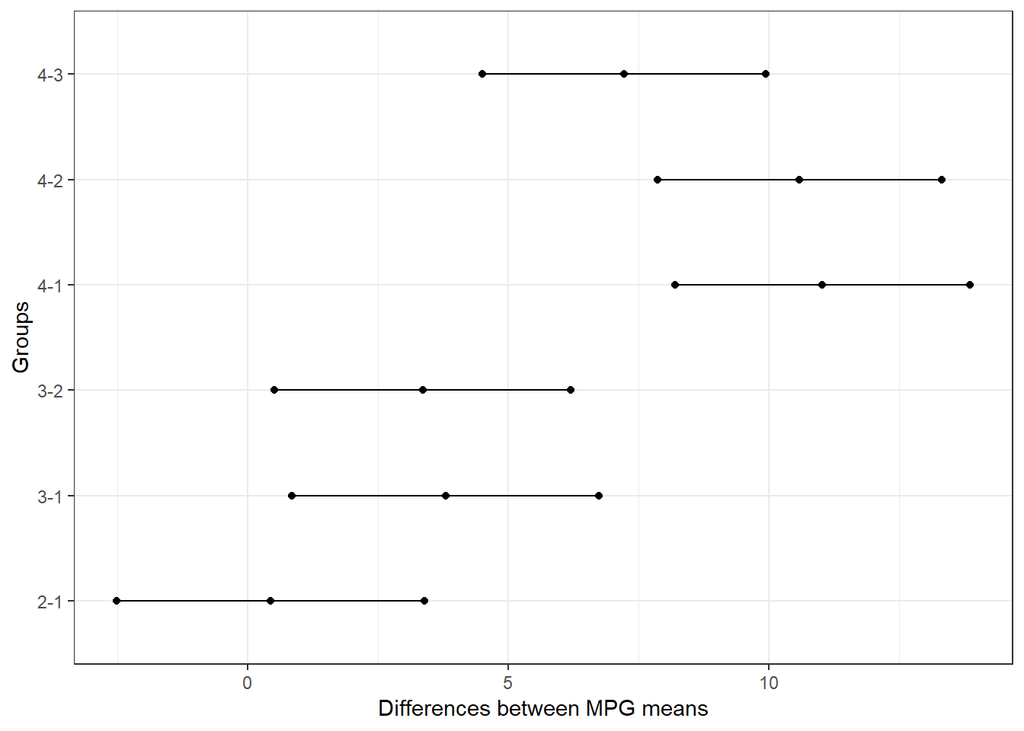

```r
#I give a name to each group
group_lwr <- rownames(DF_tuk)
group_upr <- rownames(DF_tuk)
group_diff <- rownames(DF_tuk)

values <- c(DF_tuk$lwr, DF_tuk$upr, DF_tuk$diff)
group <- c(group_lwr, group_upr, group_diff)

data <- data.frame(values, group)

ggplot(data, aes(x = values, y = group)) +
  geom_point() + geom_line() +
  labs( x = "Differences between MPG means", y = "Groups") +
  theme_bw()
```